# RNA-Seq: quantification and DE analysis

Laura Toribio-Celestino

May 2023

### Loading required packages

```r
library(Rsubread)
library(DESeq2)
library(apeglm)
library(dplyr)
library(ggplot2)
library(pheatmap)
library(RColorBrewer)
library(EnhancedVolcano)
```

# Quantification with featureCounts

Let’s start by reading the sorted BAM files and the annotation SAF file located in this directory.

```r
bamfiles <- dir(".", ".bam$")
saffile <- dir(".", "saf$")
```

Next, gene-level quantification is performed using featureCounts, which is faster than other methods and requires less computer memory. Strandness was checked before running.

```r
fc <- featureCounts(bamfiles, annot.ext=saffile, strandSpecific=2, isPairedEnd=TRUE, nthreads=15)
```

[output not shown]

[output cut: 22 more lines]

[output not shown]

Count data is exported to a TSV file. Here we’ll see some stats of the count data.

```r
write.table(x=data.frame(fc$annotation[,c("GeneID","Chr", "Length")], fc$counts, stringsAsFactors=FALSE), file="featureCounts.tsv", quote=FALSE, sep="\t", row.names=FALSE)
head(fc$counts)
```

```
##                    PF_KPN15.1.bam PF_KPN15.2.bam TC_KPN15.1.bam TC_KPN15.2.bam
## cds-pgaptmp_000001           2084           2348           2353           3552
## cds-pgaptmp_000002            982           1009           1032           1469
## cds-pgaptmp_000003            183            243            245            291
## cds-pgaptmp_000004           6689           5860           6325           7168
## cds-pgaptmp_000005           1536           1489           1605           1470
## cds-pgaptmp_000006             45             62             39             45
##                    TC_KPN15.3.bam
## cds-pgaptmp_000001           2125
## cds-pgaptmp_000002            876
## cds-pgaptmp_000003            205
## cds-pgaptmp_000004           5620
## cds-pgaptmp_000005           1339
## cds-pgaptmp_000006             41
```

```r
summary(fc$counts)
```

```
##  PF_KPN15.1.bam    PF_KPN15.2.bam    TC_KPN15.1.bam    TC_KPN15.2.bam
##  Min.   :      0   Min.   :      0   Min.   :      0   Min.   :      0
##  1st Qu.:     35   1st Qu.:     35   1st Qu.:     41   1st Qu.:     45
##  Median :    224   Median :    227   Median :    246   Median :    279
##  Mean   :   2469   Mean   :   2275   Mean   :   2301   Mean   :   2402
##  3rd Qu.:    914   3rd Qu.:    891   3rd Qu.:    972   3rd Qu.:   1085
##  Max.   :4746905   Max.   :3950735   Max.   :3683220   Max.   :4029391
##  TC_KPN15.3.bam
##  Min.   :      0
##  1st Qu.:     36
##  Median :    220
##  Mean   :   2100
##  3rd Qu.:    857
##  Max.   :3788056
```

```r
fc$stat
```

```
##                           Status PF_KPN15.1.bam PF_KPN15.2.bam TC_KPN15.1.bam
## 1                       Assigned       13838845       12750148       12896936
## 2            Unassigned_Unmapped         107205          62005          69018
## 3           Unassigned_Read_Type              0              0              0
## 4           Unassigned_Singleton              0              0              0
## 5      Unassigned_MappingQuality              0              0              0
## 6             Unassigned_Chimera              0              0              0
## 7      Unassigned_FragmentLength              0              0              0
## 8           Unassigned_Duplicate              0              0              0
## 9        Unassigned_MultiMapping              0              0              0
## 10          Unassigned_Secondary              0              0              0
## 11           Unassigned_NonSplit              0              0              0
## 12         Unassigned_NoFeatures         216182         235993         263413
## 13 Unassigned_Overlapping_Length              0              0              0
## 14          Unassigned_Ambiguity         396785         415919         459269
##    TC_KPN15.2.bam TC_KPN15.3.bam
## 1        13462439       11765894
## 2          102230         149081
## 3               0              0
## 4               0              0
## 5               0              0
## 6               0              0
## 7               0              0
## 8               0              0
## 9               0              0
## 10              0              0
## 11              0              0
## 12         295599         203678
## 13              0              0
## 14         491154         379337
```

The count matrices are prepared for the construction of the DESeqDataSet object. Gene IDs are set as row names.

```r
countdata <- fc$counts
colnames(countdata) <- gsub("\\.bam$", "", colnames(countdata))
nrow(countdata)
```

```
## [1] 5604
```

Plotting the total read counts of each sample.

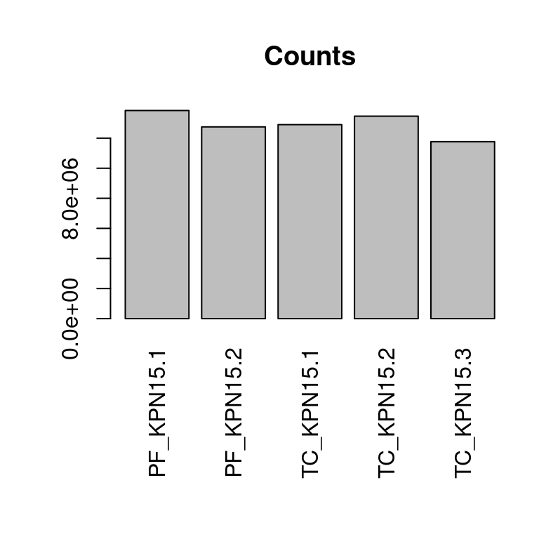

```r
par(mar=c(8,4,4,1)+0.1)
barplot(colSums(countdata), las=3, main="Counts")
```

# DESeqDataSet object and experimental design

Building the variables for the columns of the colData object. The condition of all samples and replicates is specified.

```r
condition <- c('wt', 'wt', 'tc', 'tc', 'tc')
replicate <- c('1', '2', '1', '2', '3')
coldata <- as.data.frame(cbind(colnames(countdata), condition, replicate))
coldata
```

```
##           V1 condition replicate
## 1 PF_KPN15.1        wt         1
## 2 PF_KPN15.2        wt         2
## 3 TC_KPN15.1        tc         1
## 4 TC_KPN15.2        tc         2
## 5 TC_KPN15.3        tc         3
```

Constructing the DESeqDataSet object.

```r
dds <- DESeqDataSetFromMatrix(countData = countdata, colData = coldata, design = ~ condition)
head(dds)
```

```
## class: DESeqDataSet
## dim: 6 5
## metadata(1): version
## assays(1): counts
## rownames(6): cds-pgaptmp_000001 cds-pgaptmp_000002 ...
##   cds-pgaptmp_000005 cds-pgaptmp_000006
## rowData names(0):
## colnames(5): PF_KPN15.1 PF_KPN15.2 TC_KPN15.1 TC_KPN15.2 TC_KPN15.3
## colData names(3): V1 condition replicate
```

```r
nrow(dds)
```

```
## [1] 5604
```

The reference level of the condition’s factors must be specified. The reference will be defined as the pOXA-48-free version of the strain.

```r
dds$condition <- relevel(dds$condition, ref = "wt")
```

## Pre-filtering the dataset

Rows with 0 counts will be removed to increase the speed of the DESeq2 pipeline. Additional weighting/filtering to improve power is applied at a later step in the DESeq2 workflow.

```r
keep <- rowSums(counts(dds)) > 1
dds <- dds[keep,]
nrow(dds)
```

```
## [1] 5555
```

# Analysis of count data

Before exploratory analyses, count data is transformed to stabilize the variance across the mean. The rlog transformation is applied since it works best on small datasets (n<30), in comparison with the VST method.

```r
rld <- rlog(dds, blind = FALSE)
head(assay(rld))
```

```
##                    PF_KPN15.1 PF_KPN15.2 TC_KPN15.1 TC_KPN15.2 TC_KPN15.3
## cds-pgaptmp_000001  11.121577  11.243984  11.195189  11.484077  11.221494
## cds-pgaptmp_000002   9.996216  10.029188  10.001219  10.223655   9.969700
## cds-pgaptmp_000003   7.700005   7.909949   7.876663   7.919399   7.840519
## cds-pgaptmp_000004  12.700585  12.578618  12.601681  12.610658  12.612592
## cds-pgaptmp_000005  10.587233  10.565935  10.587052  10.395243  10.537716
## cds-pgaptmp_000006   5.526630   5.657080   5.463319   5.470718   5.523865
```

### Heatmap of distances between samples

To observe the similarities and dissimilarities between samples, we plot a heatmap of Euclidean distances. Replicates from each condition should cluster together.

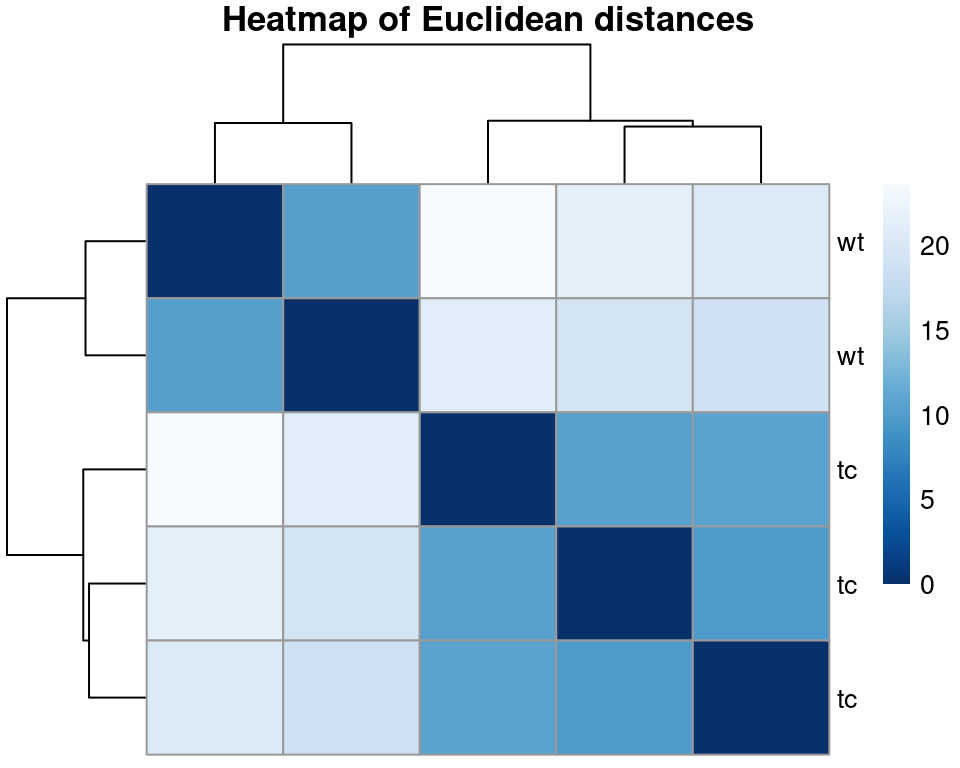

```r
sampleDists <- dist(t(assay(rld)))
sampleDistMatrix <- as.matrix(sampleDists)
rownames(sampleDistMatrix) <- paste(rld$condition, sep="-")
colnames(sampleDistMatrix) <- NULL
colors <- colorRampPalette(rev(brewer.pal(9, "Blues")))(255)
pheatmap(sampleDistMatrix,
         clustering_distance_rows=sampleDists,
         clustering_distance_cols=sampleDists,
         col=colors,
         main="Heatmap of Euclidean distances")
```

### PCA plot

In PCA plots, samples are projected onto the 2D plane such that they spread out in the two directions that explain most of the differences betweem them. The x-axis (PC1) is the direction that separates the data points the most. The y-axis (PC2) is the direction that separates the data the second most. The percent of the total variance that is contained in the direction is printed in the axis label. Replicates from each condition should cluster together.

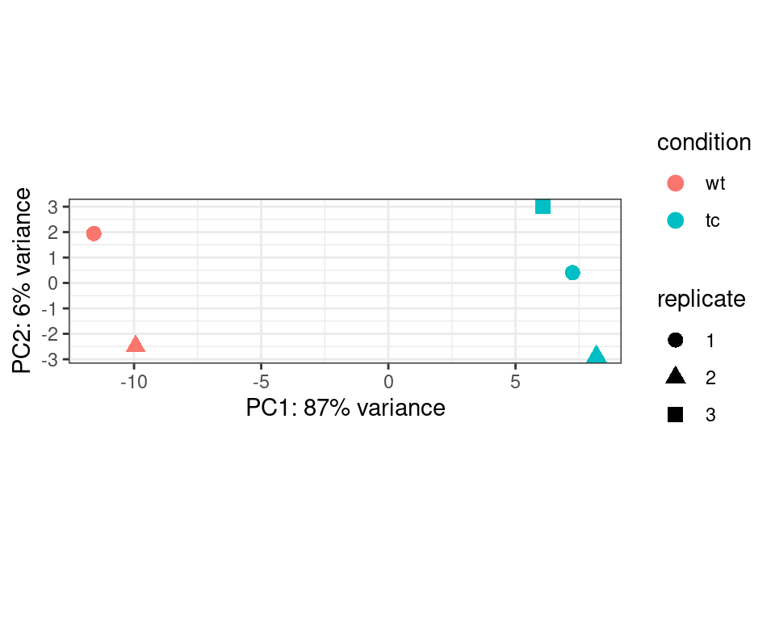

```r
pcaData <- plotPCA(rld, intgroup = c("condition", "replicate"), returnData = TRUE)
percentVar <- round(100 * attr(pcaData, "percentVar"))
ggplot(pcaData, aes(x = PC1, y = PC2, color = condition, shape = replicate)) +
  geom_point(size =3) +
  xlab(paste0("PC1: ", percentVar[1], "% variance")) +
  ylab(paste0("PC2: ", percentVar[2], "% variance")) +
  coord_fixed() +
  theme_bw()
```

## Differential expression analysis

As we have already specified an experimental design when we created the DESeqDataSet, we can run the differential expression pipeline on the raw counts:

```r
dds <- DESeq(dds)
resultsNames(dds)
```

```
## [1] "Intercept"          "condition_tc_vs_wt"
```

We’ll have a look at the summary of the unfiltered DE results. The LFC is shrunken with the apeglm method for visualizing results and ranking the genes for GSEA analysis.

```r
res <- results(dds)
res <- lfcShrink(dds, coef="condition_tc_vs_wt", type="apeglm")
```

```
## using 'apeglm' for LFC shrinkage. If used in published research, please cite:
##     Zhu, A., Ibrahim, J.G., Love, M.I. (2018) Heavy-tailed prior distributions for
##     sequence count data: removing the noise and preserving large differences.
##     Bioinformatics. https://doi.org/10.1093/bioinformatics/bty895
```

```r
res
```

```
## log2 fold change (MAP): condition tc vs wt
## Wald test p-value: condition tc vs wt
## DataFrame with 5555 rows and 5 columns
##                     baseMean log2FoldChange     lfcSE      pvalue        padj
##                    <numeric>      <numeric> <numeric>   <numeric>   <numeric>
## cds-pgaptmp_000001  2458.775      0.0895763 0.1253936    0.259549    0.742038
## cds-pgaptmp_000002  1060.079      0.0414468 0.1125780    0.578171    0.908409
## cds-pgaptmp_000003   231.441      0.0473815 0.1253076    0.505455    0.885126
## cds-pgaptmp_000004  6303.819     -0.0267975 0.0982329    0.711446    0.945809
## cds-pgaptmp_000005  1487.042     -0.0518695 0.1085906    0.489701    0.878423
## ...                      ...            ...       ...         ...         ...
## cds-pgaptmp_005626   88.1661        9.88915   2.83315 5.21102e-11 5.35555e-09
## cds-pgaptmp_005627  533.3554       12.84084   3.11627 4.21466e-17 1.20828e-14
## cds-pgaptmp_005628  145.5331       10.72722   2.91881 1.38255e-12 1.77532e-10
## cds-pgaptmp_005629  304.5381       11.93825   3.03902 4.68293e-15 1.02032e-12
## cds-pgaptmp_005547  120.1702       10.40578   2.88633 5.83165e-12 6.75851e-10
```

```r
summary(res)
```

```
##
## out of 5555 with nonzero total read count
## adjusted p-value < 0.1
## LFC > 0 (up)       : 128, 2.3%
## LFC < 0 (down)     : 133, 2.4%
## outliers [1]       : 0, 0%
## low counts [2]     : 108, 1.9%
## (mean count < 2)
## [1] see 'cooksCutoff' argument of ?results
## [2] see 'independentFiltering' argument of ?results
```

The unfiltered DE results are exported to a TSV file (contains NAs and non-significant DEGs).

```r
## The saf file, which contains the RefSeq IDs is read
saftable <- read.csv(saffile, header=TRUE, sep="\t")
saftable <- as.data.frame(saftable)
## Merge with normalized count data and annotation
resdata <- merge(as.data.frame(res), as.data.frame(counts(dds, normalized=TRUE)), by="row.names", sort=FALSE)
names(resdata)[1] <- "GeneID"
resdata <- merge(x=as.data.frame(resdata), saftable, by="GeneID")
head(resdata)
```

```
##               GeneID   baseMean log2FoldChange      lfcSE    pvalue      padj
## 1 cds-pgaptmp_000001 2458.77472     0.08957631 0.12539357 0.2595486 0.7420375
## 2 cds-pgaptmp_000002 1060.07913     0.04144675 0.11257802 0.5781710 0.9084090
## 3 cds-pgaptmp_000003  231.44138     0.04738152 0.12530759 0.5054551 0.8851259
## 4 cds-pgaptmp_000004 6303.81882    -0.02679755 0.09823293 0.7114464 0.9458093
## 5 cds-pgaptmp_000005 1487.04158    -0.05186954 0.10859057 0.4897011 0.8784229
## 6 cds-pgaptmp_000006   46.51335    -0.06722593 0.15348801 0.2304465 0.7083759
##   PF_KPN15.1 PF_KPN15.2 TC_KPN15.1 TC_KPN15.2 TC_KPN15.3 Chr Start  End Strand
## 1 2127.25096 2417.64671 2298.05645 3089.15470 2361.76479   1     1 1404      +
## 2 1002.38025 1038.92910 1007.90236 1277.58115  973.60280   1  1409 2509      +
## 3  186.79795  250.20790  239.27915  253.08109  227.84084   1  2656 3729      +
## 4 6827.82231 6033.82016 6177.30855 6233.96984 6246.17324   1  3758 6172      +
## 5 1567.87787 1533.16693 1567.52256 1278.45085 1488.18967   1  6374 7186      +
## 6   45.93392   63.83905   38.08933   39.13625   45.56817   1  7336 8418      +
##   Type         RefSeq Gene                                        Product
## 1  CDS YP_005229578.1 dnaA chromosomal replication initiator protein DnaA
## 2  CDS WP_006177590.1 dnaN                DNA polymerase III subunit beta
## 3  CDS WP_005121479.1 recF            DNA replication/repair protein RecF
## 4  CDS WP_005121480.1 gyrB  DNA topoisomerase (ATP-hydrolyzing) subunit B
## 5  CDS YP_005229574.1 yidA                              sugar-phosphatase
## 6  CDS YP_005229573.1    -                           hypothetical protein
```

```r
## Write results
write.table(resdata, file="DE_results_raw.tsv", sep="\t", row.names=FALSE)
```

Lowering the FDR threshold on padj (Benjamini-Hochberg adjusted p-values).

```r
resfilt <- results(dds, alpha = 0.05)
table(resfilt$padj < 0.05)
```

```
##
## FALSE  TRUE
##  5359   196
```

```r
resfilt
```

```
## log2 fold change (MLE): condition tc vs wt
## Wald test p-value: condition tc vs wt
## DataFrame with 5555 rows and 6 columns
##                     baseMean log2FoldChange     lfcSE      stat      pvalue
##                    <numeric>      <numeric> <numeric> <numeric>   <numeric>
## cds-pgaptmp_000001  2458.775      0.1851974  0.164261  1.127459    0.259549
## cds-pgaptmp_000002  1060.079      0.0909631  0.163585  0.556058    0.578171
## cds-pgaptmp_000003   231.441      0.1370104  0.205743  0.665931    0.505455
## cds-pgaptmp_000004  6303.819     -0.0482942  0.130555 -0.369914    0.711446
## cds-pgaptmp_000005  1487.042     -0.1023982  0.148235 -0.690784    0.489701
## ...                      ...            ...       ...       ...         ...
## cds-pgaptmp_005626   88.1661        9.60721   1.46345   6.56478 5.21102e-11
## cds-pgaptmp_005627  533.3554       12.20332   1.45161   8.40677 4.21466e-17
## cds-pgaptmp_005628  145.5331       10.32943   1.45777   7.08579 1.38255e-12
## cds-pgaptmp_005629  304.5381       11.39296   1.45408   7.83515 4.68293e-15
## cds-pgaptmp_005547  120.1702       10.05146   1.46018   6.88370 5.83165e-12
##                           padj
##                      <numeric>
## cds-pgaptmp_000001    0.753196
## cds-pgaptmp_000002    0.915593
## cds-pgaptmp_000003    0.891783
## cds-pgaptmp_000004    0.949068
## cds-pgaptmp_000005    0.886223
## ...                        ...
## cds-pgaptmp_005626 5.46174e-09
## cds-pgaptmp_005627 1.23223e-14
## cds-pgaptmp_005628 1.81052e-10
## cds-pgaptmp_005629 1.04055e-12
## cds-pgaptmp_005547 6.89251e-10
```

```r
summary(resfilt)
```

```
##
## out of 5555 with nonzero total read count
## adjusted p-value < 0.05
## LFC > 0 (up)       : 108, 1.9%
## LFC < 0 (down)     : 88, 1.6%
## outliers [1]       : 0, 0%
## low counts [2]     : 0, 0%
## (mean count < 0)
## [1] see 'cooksCutoff' argument of ?results
## [2] see 'independentFiltering' argument of ?results
```

```r
## Creating a results data frame filtered by padj and LFC
resFilt <- subset(resfilt, padj < 0.05)
## Merge with normalized count data and annotation
resdatafilt <- merge(as.data.frame(resFilt), as.data.frame(counts(dds, normalized=TRUE)), by="row.names", sort=FALSE)
names(resdatafilt)[1] <- "GeneID"
resdatafilt <- merge(x=as.data.frame(resdatafilt), saftable, by="GeneID")
head(resdatafilt)
```

```
##               GeneID    baseMean log2FoldChange     lfcSE      stat
## 1 cds-pgaptmp_000020   112.95465     -0.9522433 0.2995462 -3.178953
## 2 cds-pgaptmp_000076    38.94968     -1.7463429 0.4086342 -4.273609
## 3 cds-pgaptmp_000196  5225.03761     -0.4699859 0.1421807 -3.305554
## 4 cds-pgaptmp_000289 23242.44541     -0.4625111 0.1360482 -3.399612
## 5 cds-pgaptmp_000293  2220.92138     -0.4862694 0.1536325 -3.165147
## 6 cds-pgaptmp_000300   192.44203     -0.7200824 0.2176123 -3.309015
##         pvalue        padj  PF_KPN15.1  PF_KPN15.2  TC_KPN15.1  TC_KPN15.2
## 1 0.0014780805 0.044143748   185.77720   131.79675    54.69238    79.14220
## 2 0.0000192334 0.001068416    61.24523    73.10601    27.34619    13.04542
## 3 0.0009478893 0.032072852  6539.96974  6001.90064  4986.77272  4059.73371
## 4 0.0006748160 0.024661860 29305.84223 26335.66866 22041.02757 18917.59374
## 5 0.0015500437 0.045081113  2809.11452  2552.53246  2094.91333  1634.15588
## 6 0.0009362469 0.032072852   281.72805   221.37736   158.21723   133.06325
##    TC_KPN15.3 Chr  Start    End Strand Type         RefSeq Gene
## 1   113.36471   1  21219  22841      +  CDS YP_005229559.1    -
## 2    20.00554   1  75579  77072      +  CDS YP_005229502.1    -
## 3  4536.81124   1 200295 200585      -  CDS YP_005229377.1    -
## 4 19612.09485   1 311617 312471      +  CDS WP_008458573.1 rpoH
## 5  2013.89073   1 317081 318184      +  CDS YP_005229277.1 livJ
## 6   167.82423   1 324399 324620      +  CDS YP_005229268.1    -
##                                                                    Product
## 1                                             PTS transporter subunit EIIC
## 2                                                          MFS transporter
## 3                                       HTH-type transcriptional regulator
## 4                                         RNA polymerase sigma factor RpoH
## 5 branched chain amino acid ABC transporter substrate-binding protein LivJ
## 6                 type II toxin-antitoxin system Phd/YefM family antitoxin
```

```r
## Order by log2FC
resdatafilt <- resdatafilt[order(resdatafilt$log2FoldChange, decreasing = TRUE), ]
## Write results
write.table(resdatafilt, file="DE_results_filtered_padj.tsv", sep="\t", row.names=FALSE)
```

### MA plot

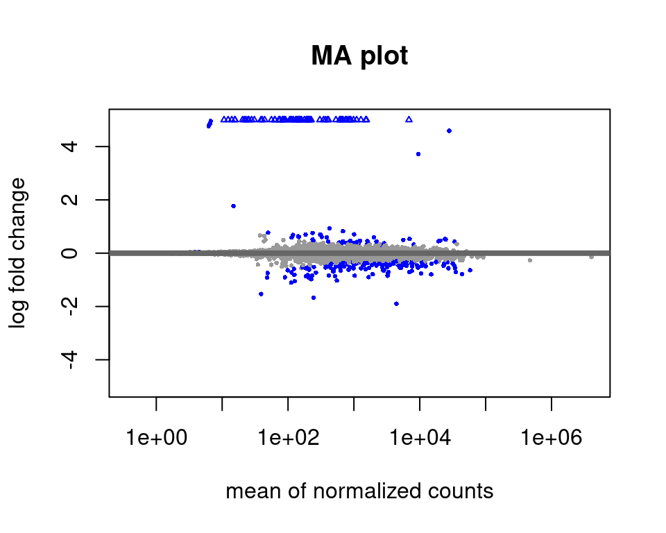

```r
DESeq2::plotMA(res, ylim=c(-5,5), main="MA plot")
```

### Volcano plot

The volcano plot arranges genes along two dimensions: the x-axis is the log fold change between the two groups, and the y-axis represents the adjusted P values between samples (on a negative log scale so smaller p-values appear higher up).

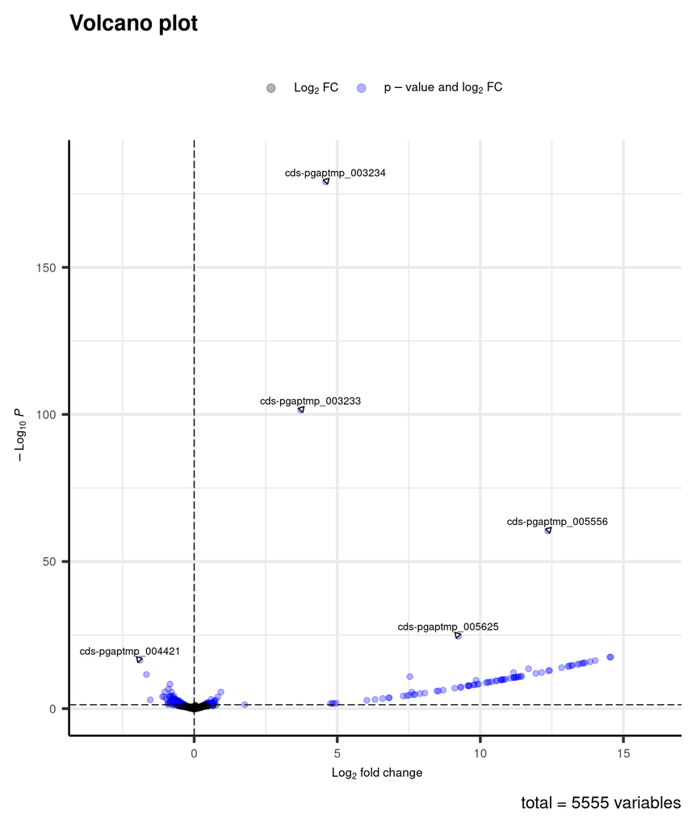

```r
EnhancedVolcano(res, lab = rownames(res), x = 'log2FoldChange', y = 'padj', pCutoff=0.05, FCcutoff=0, subtitleLabSize=0, axisLabSize=10, labSize=3, legendLabSize=10, legendIconSize=3, col=c('black', 'black', 'gold2', 'blue'), colAlpha = 0.3, drawConnectors = TRUE)
```